# Hands-on 1

Alexios Giannoulas (alexios.giannoulas01@estudiant.upf.edu)

Martí Sanchis (marti.sanchis01@estudiant.upf.edu)

Last update: 20 March, 2025

# Analysis of the Heart Disease Dataset

Load the data from [here](https://raw.githubusercontent.com/jpinero/DMI_2021/main/datasets/heart_disease_dataset.csv), and the description is [here](https://raw.githubusercontent.com/jpinero/DMI_2021/main/datasets/heart_disease_description.txt). The original dataset comes from [here](https://archive.ics.uci.edu/ml/datasets/Heart+Disease) and corresponds to the [processed cleveland data](https://archive.ics.uci.edu/ml/machine-learning-databases/heart-disease/processed.cleveland.data)

## Load DATA

```r
set.seed(123)
library(pacman)
p_load(zCompositions, here, magrittr, tidyverse, GGally, mice, rcompanion, corrplot, summarytools, gridExtra, patchwork)
dt <- read_delim(file = here("data", "heart_disease_dataset.csv"), delim = " ") %>%
  mutate(patient_id=NULL)
```

## Perform an EDA on the dataset

After loading the dataset with read_delim(), we can see that the dimensions of this tibble are 303 observations with 14 attributes, which are named as specified in the description file. However, there are two variables that don’t match the variable type specified in the descriptions: as we see in the header, variables ca and thal are detected as characters but should be categorical variables, and also the rest of categorical variables are detected as floats. Using unique() in these two first commented variables, we see that the reason they are detected as characters is because missing data are coded as a question mark “?”. There are no duplicated rows in this dataset.

To correctly parse the variables we use the mutate() function, setting all categorical variables as so (also labeling each factor as described in the description file), and also changing age variable to integer. The categorical variable heart disease diagnosis shows 4 different levels, while in the description the diagnosis can only be positive or negative, so we have changed the levels to positive and negative only. Moreover we rename variables so they have more meaningful names.

```r
dim(dt)
```

```
## [1] 303  14
```

```r
head(dt, n = 14)
```

```
## # A tibble: 14 × 14
##      age   sex    cp trestbps  chol   fbs restecg thalach exang oldpeak slope
##    <dbl> <dbl> <dbl>    <dbl> <dbl> <dbl>   <dbl>   <dbl> <dbl>   <dbl> <dbl>
##  1    63     1     1      145   233     1       2     150     0     2.3     3
##  2    67     1     4      160   286     0       2     108     1     1.5     2
##  3    67     1     4      120   229     0       2     129     1     2.6     2
##  4    37     1     3      130   250     0       0     187     0     3.5     3
##  5    41     0     2      130   204     0       2     172     0     1.4     1
##  6    56     1     2      120   236     0       0     178     0     0.8     1
##  7    62     0     4      140   268     0       2     160     0     3.6     3
##  8    57     0     4      120   354     0       0     163     1     0.6     1
##  9    63     1     4      130   254     0       2     147     0     1.4     2
## 10    53     1     4      140   203     1       2     155     1     3.1     3
## 11    57     1     4      140   192     0       0     148     0     0.4     2
## 12    56     0     2      140   294     0       2     153     0     1.3     2
## 13    56     1     3      130   256     1       2     142     1     0.6     2
## 14    44     1     2      120   263     0       0     173     0     0       1
## # ℹ 3 more variables: ca <chr>, thal <chr>, num <dbl>
```

```r
unique(dt$ca)
```

```
## [1] "0" "3" "2" "1" "?"
```

```r
unique(dt$thal)
```

```
## [1] "6" "3" "7" "?"
```

```r
# unique(dt$num)
# summary(dt$sex %>% as.factor())
dt[duplicated(dt),]
```

```
## # A tibble: 0 × 14
## # ℹ 14 variables: age <dbl>, sex <dbl>, cp <dbl>, trestbps <dbl>, chol <dbl>,
## #   fbs <dbl>, restecg <dbl>, thalach <dbl>, exang <dbl>, oldpeak <dbl>,
## #   slope <dbl>, ca <chr>, thal <chr>, num <dbl>
```

```r
### Numerical (Discrete/continuous)
# age (numeric discrete): Age in years
# trestbps (numeric): Resting blood pressure (mm Hg)
# chol (numeric): Serum cholesterol (mg/dl)
# thalach (numeric continuous): Maximum heart rate achieved
# oldpeak (numeric continuous): ST depression induced by exercise relative to rest

### Categorical
# sex (factor): 1 = male, 0 = female
# cp: (factor) Chest pain type (1: typical angina, 2: atypical angina, 3: non-anginal pain, 4: asymptomatic)
# fbs (factor): Fasting blood sugar > 120 mg/dl (1 = true, 0 = false)
# restecg (factor): Resting electrocardiographic results (0: normal, 1: ST-T wave abnormality, 2: left ventricular hypertrophy)
# exang (factor): Exercise-induced angina (1 = yes, 0 = no)
# slope (factor): Slope of the peak exercise ST segment (1: upsloping, 2: flat, 3: downsloping)
# ca (factor): Number of major vessels colored by fluoroscopy
# thal (factor): Thalassemia (3: normal, 6: fixed defect, 7: reversible defect)
# num (factor): Diagnosis of heart disease (1: > 50% diameter narrowing, 0: < 50% narrowing)

heart_disease <- dt %>%
  mutate(
    sex = factor(sex, levels = c("0", "1"), labels = c("female", "male")),
    cp = factor(cp, levels = c("1", "2", "3", "4"), labels = c("typical","atypical","non-anginal","asymptomatic")),
    trestbps = as.double(trestbps),
    chol = as.double(chol),
    fbs = factor(fbs, levels = c("0","1"),labels = c("<120mg/dl", ">120mg/dl")),
    restecg = factor(restecg, levels = c("0","1","2"), labels = c("normal", "abnormal", "hypertrophy")),
    thalach = as.double(thalach),
    exang = factor(exang, levels = c("0","1"),labels = c("not", "yes")),
    oldpeak = as.double(oldpeak),
    slope = factor(slope, levels = c("1","2","3"), labels = c("upsloping", "flat", "downsloping")),
    ca = factor(na_if(ca, "?"), levels = c("0","1","2","3")),
    thal = factor(na_if(thal, "?"), levels = c("3","6","7"), labels = c("normal", "fixed", "reversible")),
    num = factor(ifelse(num == "0", "negative", "positive"))
  ) %>%
    rename(
      Gender=sex,
      Age=age,
      ChestPain = cp,
      RestingBloodPressure = trestbps,
      Cholesterol = chol,
      FastingBloodSugar = fbs,
      RestingECG = restecg,
      MaxHeartRate = thalach,
      ExerciseInducedAngina = exang,
      STDepression = oldpeak,
      Slope=slope,
      MajorVessels = ca,
      Thalassemia = thal,
      Diagnosis = num
  )
head(heart_disease)
```

```
## # A tibble: 6 × 14
##     Age Gender ChestPain    RestingBloodPressure Cholesterol FastingBloodSugar
##   <dbl> <fct>  <fct>                       <dbl>       <dbl> <fct>
## 1    63 male   typical                       145         233 >120mg/dl
## 2    67 male   asymptomatic                  160         286 <120mg/dl
## 3    67 male   asymptomatic                  120         229 <120mg/dl
## 4    37 male   non-anginal                   130         250 <120mg/dl
## 5    41 female atypical                      130         204 <120mg/dl
## 6    56 male   atypical                      120         236 <120mg/dl
## # ℹ 8 more variables: RestingECG <fct>, MaxHeartRate <dbl>,
## #   ExerciseInducedAngina <fct>, STDepression <dbl>, Slope <fct>,
## #   MajorVessels <fct>, Thalassemia <fct>, Diagnosis <fct>
```

```r
summarytools::dfSummary(heart_disease) %>%
  print(method="render")
```

[output not shown]

Data Frame Summary

**Dimensions**: 303 x 14  
**Duplicates**: 0

| **No** | **Variable** | **Stats / Values** | **Freqs (% of Valid)** | **Graph** | **Valid** | **Missing** |
| --- | --- | --- | --- | --- | --- | --- |
| 1 | Age [numeric] | Mean (sd) : 54.4 (9) min ≤ med ≤ max: 29 ≤ 56 ≤ 77 IQR (CV) : 13 (0.2) | 41 distinct values |  | 303 (100.0%) | 0 (0.0%) |
| 2 | Gender [factor] | 1. female 2. male | 97 ( 32.0% ) 206 ( 68.0% ) |  | 303 (100.0%) | 0 (0.0%) |
| 3 | ChestPain [factor] | 1. typical 2. atypical 3. non-anginal 4. asymptomatic | 23 ( 7.6% ) 50 ( 16.5% ) 86 ( 28.4% ) 144 ( 47.5% ) |  | 303 (100.0%) | 0 (0.0%) |
| 4 | RestingBloodPressure [numeric] | Mean (sd) : 131.7 (17.6) min ≤ med ≤ max: 94 ≤ 130 ≤ 200 IQR (CV) : 20 (0.1) | 50 distinct values |  | 303 (100.0%) | 0 (0.0%) |
| 5 | Cholesterol [numeric] | Mean (sd) : 246.7 (51.8) min ≤ med ≤ max: 126 ≤ 241 ≤ 564 IQR (CV) : 64 (0.2) | 152 distinct values |  | 303 (100.0%) | 0 (0.0%) |
| 6 | FastingBloodSugar [factor] | 1. <120mg/dl 2. >120mg/dl | 258 ( 85.1% ) 45 ( 14.9% ) |  | 303 (100.0%) | 0 (0.0%) |
| 7 | RestingECG [factor] | 1. normal 2. abnormal 3. hypertrophy | 151 ( 49.8% ) 4 ( 1.3% ) 148 ( 48.8% ) |  | 303 (100.0%) | 0 (0.0%) |
| 8 | MaxHeartRate [numeric] | Mean (sd) : 149.6 (22.9) min ≤ med ≤ max: 71 ≤ 153 ≤ 202 IQR (CV) : 32.5 (0.2) | 91 distinct values |  | 303 (100.0%) | 0 (0.0%) |
| 9 | ExerciseInducedAngina [factor] | 1. not 2. yes | 204 ( 67.3% ) 99 ( 32.7% ) |  | 303 (100.0%) | 0 (0.0%) |
| 10 | STDepression [numeric] | Mean (sd) : 1 (1.2) min ≤ med ≤ max: 0 ≤ 0.8 ≤ 6.2 IQR (CV) : 1.6 (1.1) | 40 distinct values |  | 303 (100.0%) | 0 (0.0%) |
| 11 | Slope [factor] | 1. upsloping 2. flat 3. downsloping | 142 ( 46.9% ) 140 ( 46.2% ) 21 ( 6.9% ) |  | 303 (100.0%) | 0 (0.0%) |
| 12 | MajorVessels [factor] | 1. 0 2. 1 3. 2 4. 3 | 176 ( 58.9% ) 65 ( 21.7% ) 38 ( 12.7% ) 20 ( 6.7% ) |  | 299 (98.7%) | 4 (1.3%) |
| 13 | Thalassemia [factor] | 1. normal 2. fixed 3. reversible | 166 ( 55.1% ) 18 ( 6.0% ) 117 ( 38.9% ) |  | 301 (99.3%) | 2 (0.7%) |
| 14 | Diagnosis [factor] | 1. negative 2. positive | 164 ( 54.1% ) 139 ( 45.9% ) |  | 303 (100.0%) | 0 (0.0%) |

Generated by summarytools 1.1.2 ([R](https://www.r-project.org/) version 4.4.1)  
2025-03-20

We use the function zPatterns from the package zCompositions to plot the different patterns of missingness in this dataset. We can observe that very few observations have missing data, only in the two variables mentioned above: vessels_count and thalassemia. Note also that the missingness in the two variables are independent from each other, so most probably these are missing completely at random. Taking into account that only a 2% of observations contain missing data, we could just simply remove these records from the dataset.

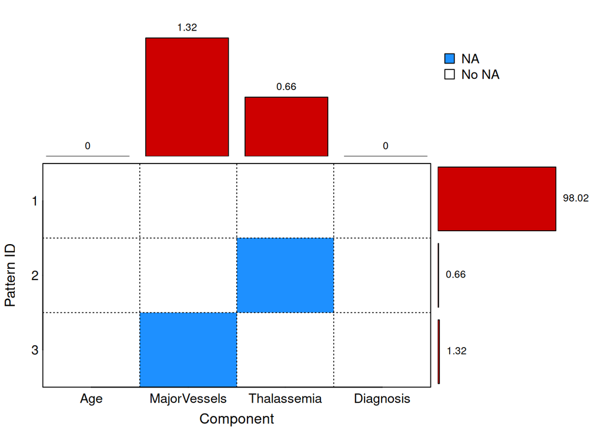

```
## Patterns ('+' means NA, '-' means No NA)
##
##  Patt.ID Age MajorVessels Thalassemia Diagnosis No.Unobs Patt.Perc
##        1   -            -           -         -        0     98.02
##        2   -            -           +         -        1      0.66
##        3   -            +           -         -        1      1.32
##
## Percentage cells by component
##          Age MajorVessels  Thalassemia    Diagnosis
##         0.00         1.32         0.66         0.00
##
## Overall percentage cells: 0.5%
```

```r
heart_disease %>%
  dplyr::select(c(Age,MajorVessels,Thalassemia,Diagnosis)) %>%
  zPatterns(label = NA, bar.labels = TRUE)
```

```r
imputed_data <- mice(heart_disease, method = "polyreg",printFlag = FALSE)
heart_disease_imputed <- complete(imputed_data)

summary(heart_disease %>% dplyr::select(MajorVessels,Thalassemia))
```

```
##  MajorVessels     Thalassemia
##  0   :176     normal    :166
##  1   : 65     fixed     : 18
##  2   : 38     reversible:117
##  3   : 20     NA's      :  2
##  NA's:  4
```

```r
summary(heart_disease_imputed %>% dplyr::select(MajorVessels,Thalassemia))
```

```
##  MajorVessels     Thalassemia
##  0:179        normal    :167
##  1: 65        fixed     : 19
##  2: 38        reversible:117
##  3: 21
```

Afterwards, we create two different tibbles containing only the numerical variables or the categorical variables. We use the pivot_longer function to reorganize the tibble in a way that the information of attribute is no longer a set of different columns but a single column. The levels of this column are the variable names. The second column contains the corresponding values for all levels. This allows us to make univariate plots for all variables within a single ggplo2 call:

First we plot the histograms from the numerical variables with the density line. The distribution of variable st_depression is heavily zero-inflated and also probably present some outliers in its right tail, deviating the most from a normal distribution. Other variables also present skewed distributions and probably some outliers. Age is the only variable close to a normal distribution.

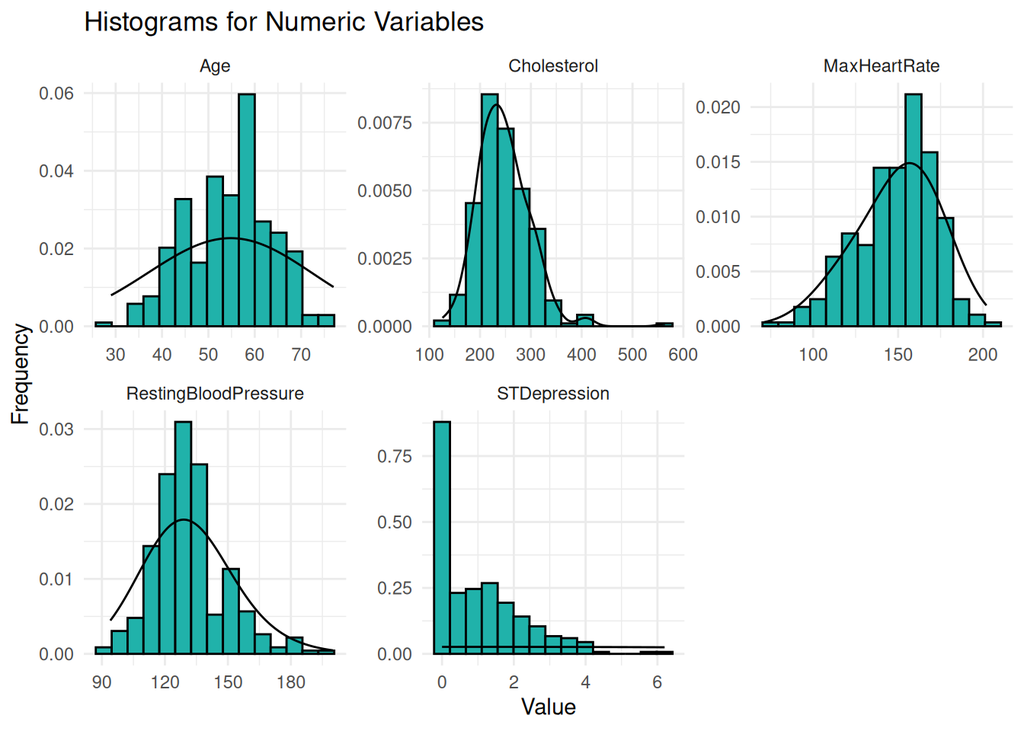

```r
numerical_long <- heart_disease_imputed %>%
  pivot_longer(cols = where(is.numeric), names_to = "Variables", values_to = "Value") %>%
  dplyr::select(Variables, Value)

numerical_long %>% ggplot(aes(x = Value)) +
  geom_histogram(aes(y = after_stat(density)), bins=15, fill = "lightseagreen", color = "black") +
  geom_density(bw=15) +
  facet_wrap(~ Variables, scales = "free") +
  theme_minimal() +
  labs(title = "Histograms for Numeric Variables",
       x = "Value",
       y = "Frequency")
```

Also we use the qq-plots to visualize if they are normally distributed. Variables age, cholesterol, max_hr and rest_bsp align quite well with most of the QQplots, but the tails don’t fit really well. Both cholesterol and rest_bps appear to be slightly positively skewed with a heavier right tail and may present some outliers. On the other hand, max_hr shows a slight negative skewness with a heavier left tail.

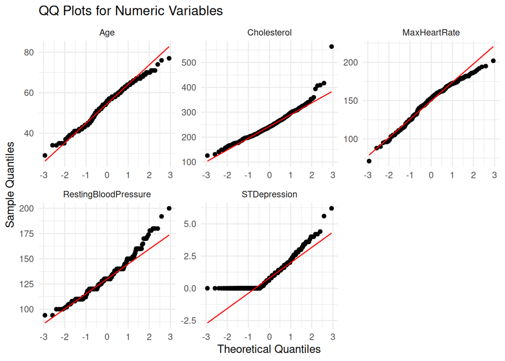

```r
numerical_long %>% ggplot(aes(sample = Value)) +
  geom_qq() +
  geom_qq_line(color = "red") +
  facet_wrap(~ Variables, scales = "free") +
  theme_minimal() +
  labs(title = "QQ Plots for Numeric Variables",
       x = "Theoretical Quantiles",
       y = "Sample Quantiles")
```

When checking the normality of the numerical variables with the shapiro.wilk test, the assumption of normality is rejected for all of them. We try to use the log values and still normality is rejected for most variables, except from cholesterol.

```r
numerical_long %>%
  group_by(Variables) %>%
  summarise(
    p_value = shapiro.test(Value)$p.value)
```

```
## # A tibble: 5 × 2
##   Variables             p_value
##   <chr>                   <dbl>
## 1 Age                  6.07e- 3
## 2 Cholesterol          5.91e- 9
## 3 MaxHeartRate         7.00e- 5
## 4 RestingBloodPressure 1.80e- 6
## 5 STDepression         8.18e-17
```

```r
numerical_long %>%
  group_by(Variables) %>%
  summarise(
    p_value = shapiro.test(log(Value))$p.value)
```

```
## # A tibble: 5 × 2
##   Variables               p_value
##   <chr>                     <dbl>
## 1 Age                    2.18e- 6
## 2 Cholesterol            1.07e- 1
## 3 MaxHeartRate           9.39e-10
## 4 RestingBloodPressure   9.63e- 3
## 5 STDepression         NaN
```

In the univariate boxplots we can see that some variables like Cholesterol RestingBloodPressure and STDepression have in fact some outliers. In order to adress them, the mahalanobis_distance function from package rstatix is used. This is a multivariate algorithm that uses the mahalanobis distance to flag outliers, also taking into account the covariance matrix of the set of variables. In this way, some of the univariate outliers are not flagged as so.

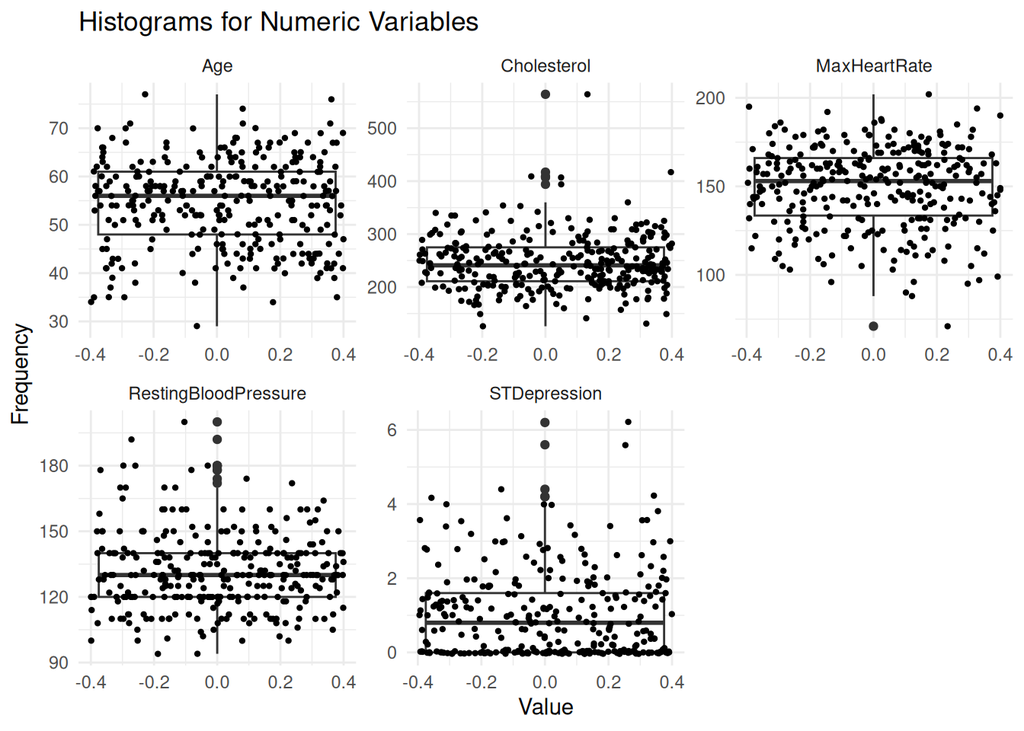

```r
numerical_long %>% ggplot(aes(y = Value)) +
  geom_boxplot() +
  geom_jitter(aes(x = 0), size=0.8) +
  facet_wrap(~ Variables, scales = "free") +
  theme_minimal() +
  labs(title = "Histograms for Numeric Variables",
       x = "Value",
       y = "Frequency")
```

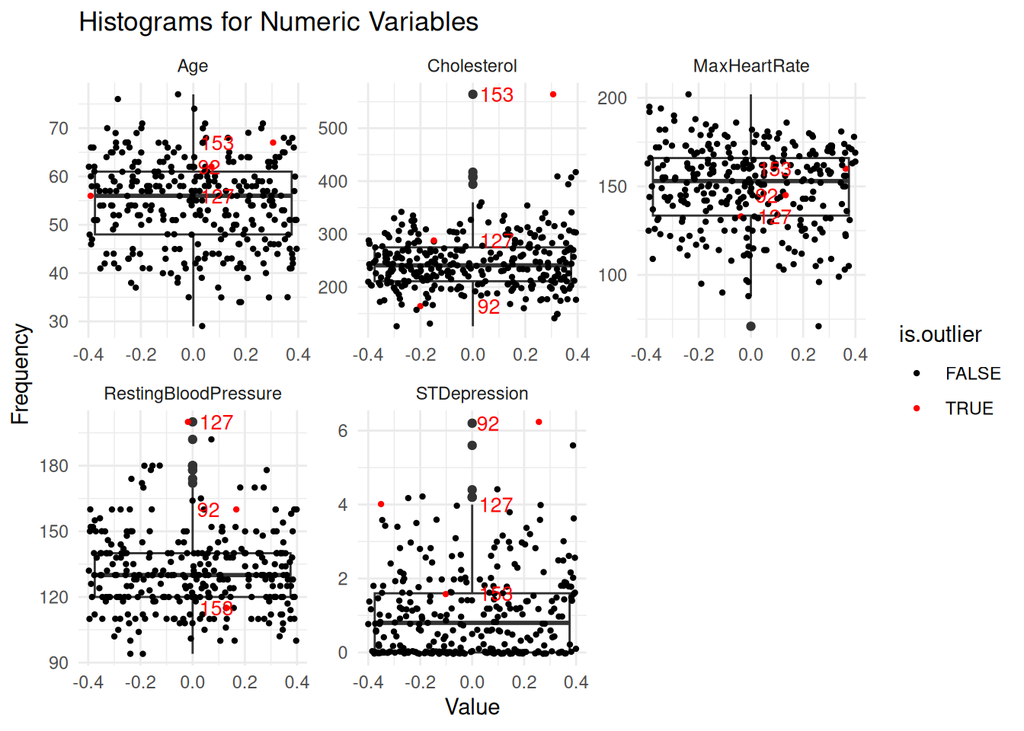

```r
heart_disease_imputed %<>% add_column(rstatix::mahalanobis_distance(heart_disease_imputed) %>%
                                        dplyr::select(is.outlier)) %>%
  mutate(id=row_number())

numerical_long <- heart_disease_imputed %>%
  pivot_longer(cols = where(is.numeric)& !c("id"),
               names_to = "Variables",
               values_to = "Value") %>%
  dplyr::select(Variables, Value, is.outlier, id)

numerical_long %>% ggplot(aes(y = Value)) +
  geom_boxplot() +
  geom_jitter(aes(x = 0, colour = is.outlier), size=0.8) +
  geom_text(
    data = numerical_long %>% filter(is.outlier == TRUE),
    aes(x = 0, label = id),
    hjust = -0.2,
    size = 3.5,
    color = "red"
  ) +
  facet_wrap(~ Variables, scales = "free") +
  theme_minimal() +
  labs(title = "Histograms for Numeric Variables",
       x = "Value",
       y = "Frequency") +
  scale_color_manual(values = c("FALSE" = "black", "TRUE" = "red"))
```

```r
variables_outliers <- list(
  "Cholesterol" = 153,
  "RestingBloodPressure" = 127,
  "STDepression"  = 92)

for (var in names(variables_outliers)) {
  Q1 <- unname(quantile(heart_disease_imputed[[var]], 0.25))
  Q3 <- unname(quantile(heart_disease_imputed[[var]], 0.75))
  IQR <- Q3 - Q1
  upper_limit <- Q3 + 1.5 * IQR
  lower_limit <- Q1 - 1.5 * IQR
  heart_disease_imputed[variables_outliers[[var]],var] <- upper_limit
}

rstatix::mahalanobis_distance(heart_disease_imputed) %>%
  dplyr::select(is.outlier) %>%
  any()
```

```
## [1] FALSE
```

Ending this univariate part, we use barplots for the categorical variables. We can see that many variables’ levels are unbalanced. Resting ECG, Slope and Thalassemia have two balanced levels but a third level with very few counts. Gender, Exercise Induced Angina are a little more balanced and the diagnosis variable is well balanced, with almost equal negative and positive diagnosis.

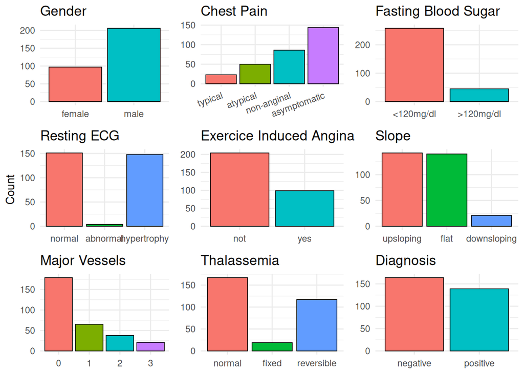

The scatter plots and correlation coefficients indicate weak relationships between most numerical variables, but a few notable trends emerge:  
- Max Heart Rate decreases with Age: This aligns with the physiological decline in cardiovascular efficiency, where the heart’s ability to reach high rates diminishes with age.  
- ST Depression decreases with Max Heart Rate: Individuals with higher max heart rates may have better cardiovascular health, while those with significant ST depression often have underlying cardiovascular issues.  
- Resting Blood Pressure increases with Age: Aging leads to reduced arterial elasticity and increased vascular resistance, contributing to higher blood pressure over time.

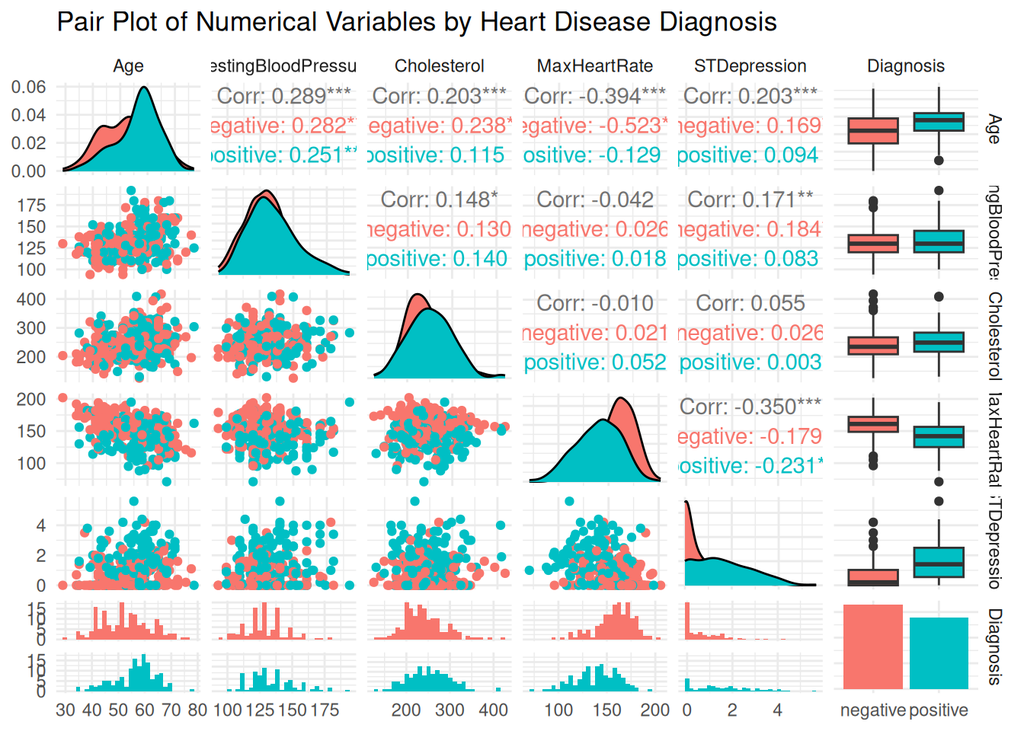

```r
ggpairs(heart_disease_imputed,
        columns = c("Age", "RestingBloodPressure", "Cholesterol", "MaxHeartRate", "STDepression", "Diagnosis"),
        aes(color = Diagnosis),
        progress = FALSE) +
  theme_minimal() +
  labs(title = "Pair Plot of Numerical Variables by Heart Disease Diagnosis")
```

## Create visualizations in order to show which variables seem to be more associated with heart disease

In order to identify the variables most associated with heart disease, we first compute the correlation matrix between the numerical variables and diagnosis. As diagnosis is a binary categorical variable, we can convert it to numerical and compute the correlation. This would not make sense with a nominal variable with more than two levels, as they wouldn’t have any meaningful order. In this case, 0 is negative diagnosis, and 1 is positive diagnosis. Therefore, variables with positive correlation are associated to having the disease, whereas variables with negative correlation are associated with no disease.

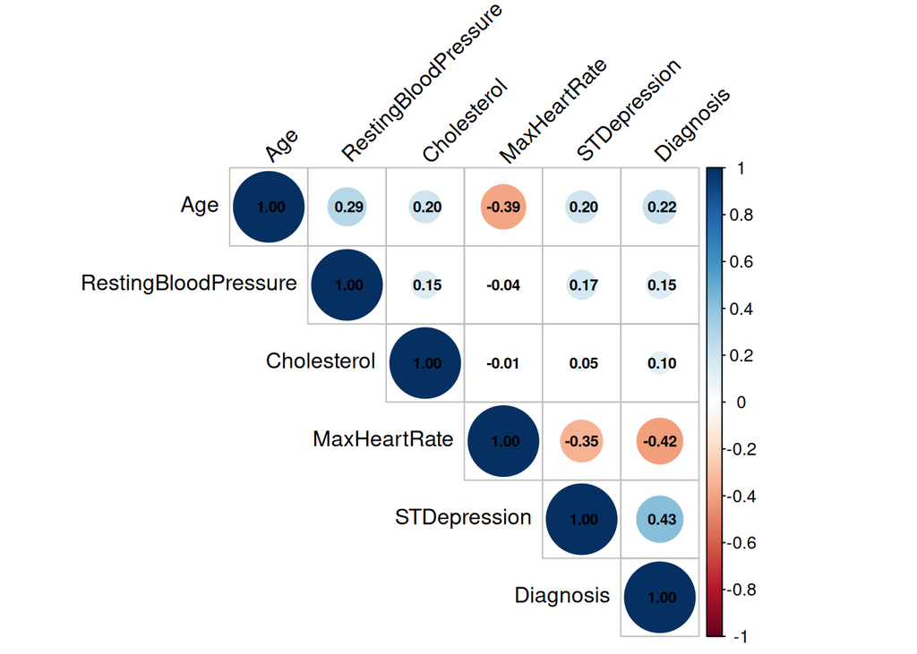

```r
cormat <- cor(heart_disease_imputed %>%
                select(where(is.numeric), -id, Diagnosis) %>%
                mutate(Diagnosis = as.numeric(Diagnosis)))
corrplot(cormat, type = "upper", tl.col = "black", tl.srt = 45, addCoef.col = "black", number.cex = 0.7)
```

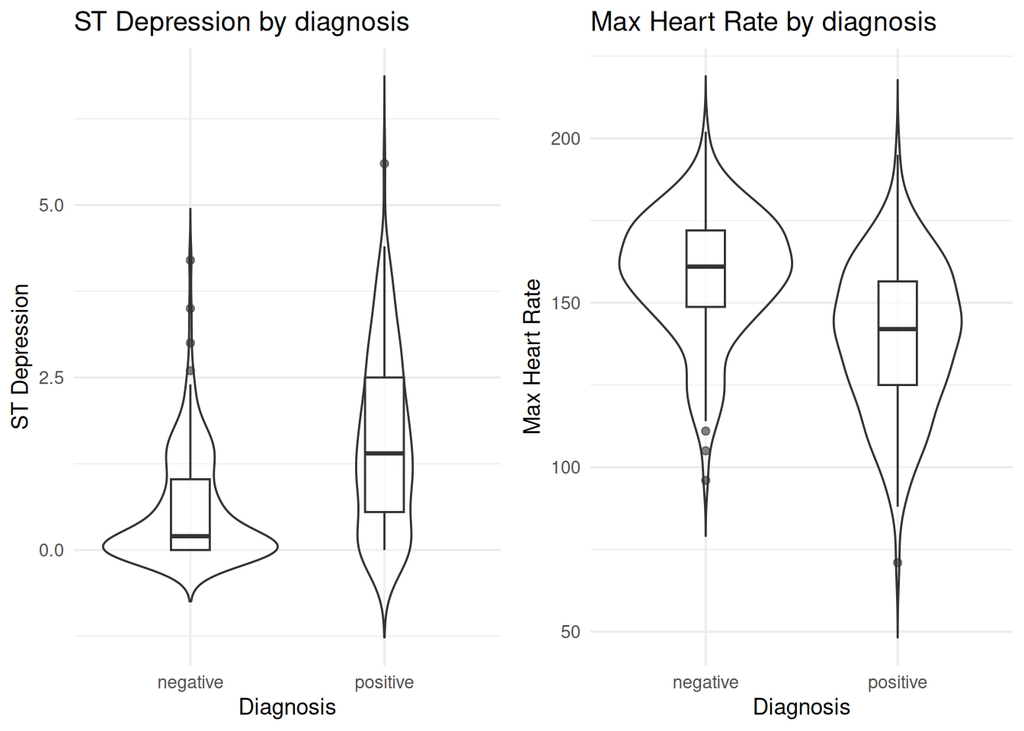

```r
boxplot1 <- ggplot(heart_disease_imputed, aes(x=Diagnosis, y=STDepression))+
  geom_violin(alpha = 0.3, trim = FALSE) +
  geom_boxplot(width = 0.2, alpha = 0.6) +
  theme_minimal() +
  labs(title = "ST Depression by diagnosis",
       x = "Diagnosis",
       y = "ST Depression")

boxplot2 <- ggplot(heart_disease_imputed, aes(x=Diagnosis, y=MaxHeartRate))+
  geom_violin(alpha = 0.3, trim = FALSE) +
  geom_boxplot(width = 0.2, alpha = 0.6) +
  theme_minimal() +
  labs(title = "Max Heart Rate by diagnosis",
       x = "Diagnosis",
       y = "Max Heart Rate")
grid.arrange(boxplot1, boxplot2, ncol = 2)
```

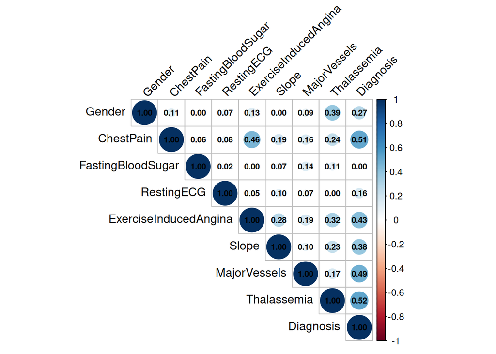

```r
categorical_vars <- names(heart_disease_imputed %>% dplyr::select(where(is.factor), -id))
cramermat <- matrix(NA, ncol = length(categorical_vars), nrow = length(categorical_vars),
                    dimnames = list(categorical_vars, categorical_vars))
for (i in 1:length(categorical_vars)) {
  for (j in 1:length(categorical_vars)) {
    if (i == j) {
      cramermat[i, j] <- 1
    } else {
      cramermat[i, j] <- cramerV(heart_disease_imputed[[categorical_vars[i]]],
                                      heart_disease_imputed[[categorical_vars[j]]],
                                      bias.correct = TRUE)
    }}}
corrplot(cramermat, type = "upper",
         tl.col = "black", tl.srt = 45,
         addCoef.col = "black",
         number.cex = 0.7)
```

Finally, we present the bar plots for the aforementioned categorical variables in relation to Diagnosis. Also the resulting p-values from the chi-squared and Fisher’s exact tests are presented:  
- Gender: Male patients tend to have a higher proportion of positive diagnoses compared to females, which aligns with the well-documented higher prevalence of heart disease in men.  
- Chest Pain Type: Surprisingly, positive diagnoses are most associated with asymptomatic (no chest pain) cases. This suggests that many patients with significant narrowing of the coronary artery may not experience typical chest pain.  
- Exercise-Induced Angina: Patients who experience angina during exercise show a higher likelihood of a positive diagnosis.  
- Slope of the ST Segment: Those with flat or downsloping ST segments are more likely to have heart disease, as these patterns often indicate ischemia: lack of oxygen supply to the cardiac muscle.  
- Major Vessels (colored by fluoroscopy): Patients with one or more colored major vessels tend to have more positive diagnoses.This variable is a bit confusing as it is it seems to refer to colored vessels that are not obstructed. Obstructed vessels are indicators of cardiac pathology, so we would think of a lower number of MajorVesels to be associated with the disease.  
- Thalassemia: The presence of reversible and fixed Thalassemia is strongly associated with positive diagnoses, possibly due to its link with reduced blood oxygenation and increased cardiac stress.

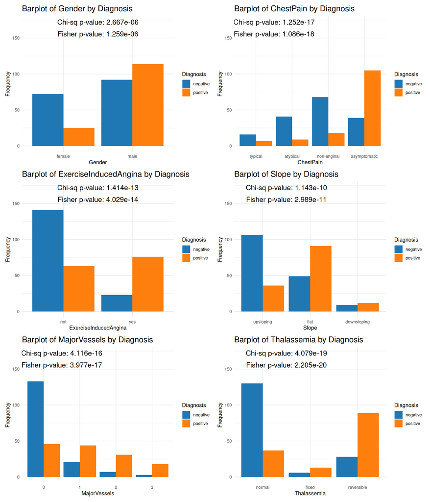

```r
plot_chisq_fisher_barplot <- function(data, var1, var2) {
  contingency_table <- table(data[[var1]], data[[var2]])

  chi_square_result <- chisq.test(contingency_table)
  chi_p_value <- chi_square_result$p.value
  fisher_result <- fisher.test(contingency_table)
  fisher_p_value <- fisher_result$p.value

  p <- ggplot(data, aes_string(x = var1, fill = var2)) +
    geom_bar(position = "dodge") +
    labs(title = paste("Barplot of", var1, "by", var2),
         x = var1,
         y = "Frequency") +
    scale_fill_manual(values = c("#1f77b4", "#ff7f0e","darkred","lightgreen")) +
    theme_minimal() +
    theme(plot.title = element_text(size = 16))  # Ajusta el tamaño del título
  p + annotate("text", x = 1.5, y = max(table(data[[var2]])) * 1.05,
               label = paste("Chi-sq p-value:", format(chi_p_value, scientific = TRUE, digits = 4)),
               size = 5, hjust = 0.5, color = "black") +
    annotate("text", x = 1.5, y = max(table(data[[var2]])) * 0.95,
             label = paste("Fisher p-value:", format(fisher_p_value, scientific = TRUE, digits = 4)),
             size = 5, hjust = 0.5, color = "black")
}

barplot1 <- plot_chisq_fisher_barplot(heart_disease_imputed, "Gender", "Diagnosis")
barplot2 <- plot_chisq_fisher_barplot(heart_disease_imputed, "ChestPain", "Diagnosis")
barplot3 <- plot_chisq_fisher_barplot(heart_disease_imputed, "ExerciseInducedAngina", "Diagnosis")
barplot4 <- plot_chisq_fisher_barplot(heart_disease_imputed, "Slope", "Diagnosis")
barplot5 <- plot_chisq_fisher_barplot(heart_disease_imputed, "MajorVessels", "Diagnosis")
barplot6 <- plot_chisq_fisher_barplot(heart_disease_imputed, "Thalassemia", "Diagnosis")

(barplot1 + barplot2) / (barplot3 + barplot4) / (barplot5 + barplot6)
```

# 2 Difference in mortality rates in hospitalized COVID-19 patients

Using the supplementary material from the [Difference in mortality rates in hospitalized COVID-19 patients identified by cytokine profile clustering using a machine learning approach: An outcome prediction alternative](https://www.frontiersin.org/articles/10.3389/fmed.2022.987182/full), perform the following tasks

## Reproduce Figure 1 from the publication

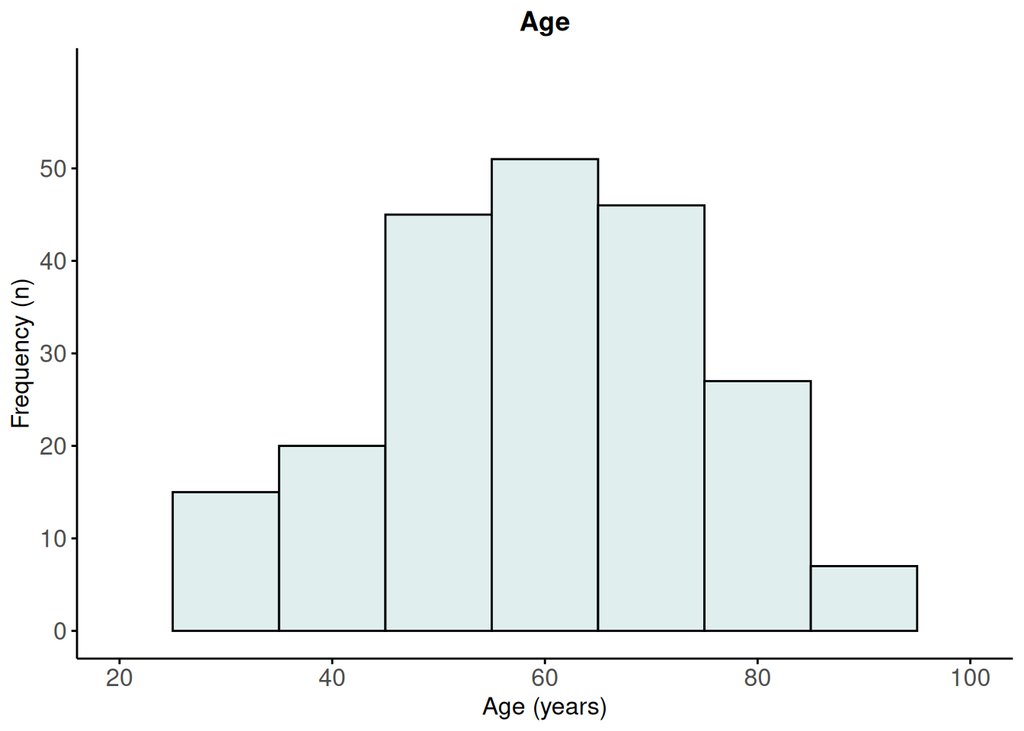

```r
# setwd("/home/alexiosgiannoulas/DMI/Practical_1/assignment-1-alexiosvg")
library(readxl)
library(here)
library(dplyr)
library(ggpubr)
library(RColorBrewer)
library(tibble)
library(ggplot2)

#Loading the table with the clinical characteristics of the patients, skipping the first line
data <-read_excel(here("data", "Table 1.XLSX"), skip = 1)
#Plotting the distribution of age among patients

Plot1A <- ggplot(data, aes(x = Age)) +
  geom_histogram(binwidth = 10, fill = "azure2", color = "black") +
  labs(title = "Age", x = "Age (years)", y = "Frequency (n)") +
  scale_x_continuous(limits = c(20, 100), breaks = seq(20, 100, by = 20)) +
  scale_y_continuous(limits = c(0, 60), breaks = seq(0, 50, by = 10)) +
  theme_minimal() +
  theme(
    panel.grid = element_blank(),
    axis.line = element_line(color = "black"),
    axis.ticks = element_line(color = "black"),
    plot.title = element_text(hjust = 0.5, face = "bold"),
    axis.text = element_text(size = 12),
    axis.title = element_text(size = 12)
  )
Plot1A
```

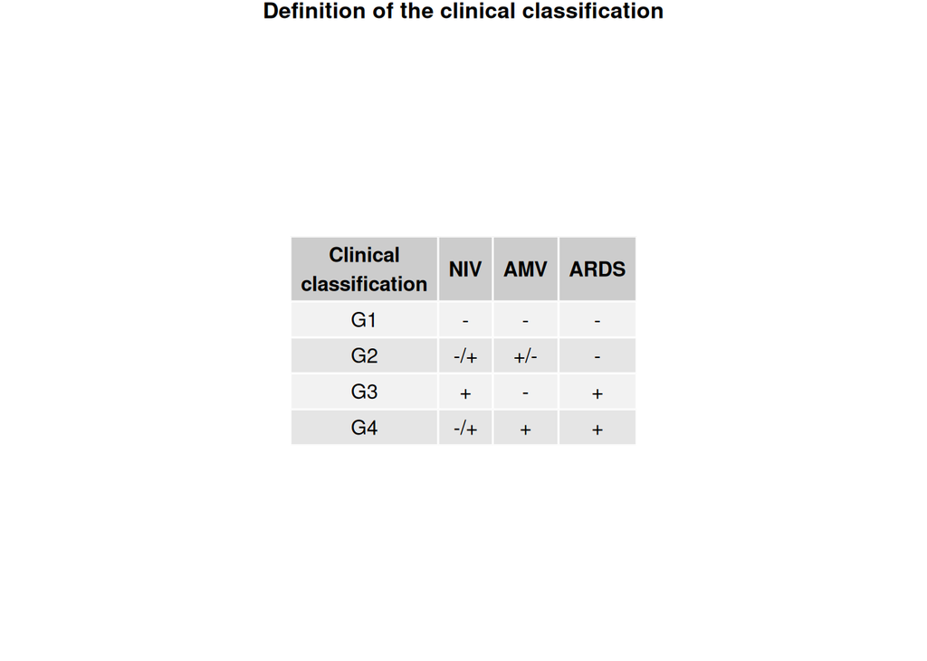

```r
#Making a custom table  for PlotB
Plot1B <- tribble(
  ~"Clinical\nclassification", ~"NIV", ~"AMV", ~"ARDS",
  "G1", "-", "-", "-",
  "G2", "-/+", "+/-", "-",
  "G3", "+", "-", "+",
  "G4", "-/+", "+", "+"
)

#Making a custom theme for the table
custom_theme <- ttheme(
  colnames.style = list(
    face = "bold", size = 14, color = "black", fill = "grey70", halign = "center"
  ),
  tbody.style = list(
    size = 12, color = "black", fill = c("white", "grey90"), halign = "center"
  )
)

# Generating the table plot
table_plot1B <- ggtexttable(Plot1B,
                          rows = NULL,
                          theme = custom_theme)+
  ggtitle("Definition of the clinical classification") +
  theme(
    plot.title = element_text(
      hjust = 0.5,
      size = 12,     # Adjust size to match your script (increase for larger text)
      face = "bold"   # Make it bold
    )
  )
table_plot1B
```

Some data cleaning has to be done before making the rest of the figures

```r
# Deleting duplicated rows
data <- data %>% distinct()
#Filter the data to only keep the rows where the data is correctly entered
#To avoid spaces we use trimws
data <- data %>%
  filter(
    trimws(`ARDS Diagnosis`) %in% c("Yes", "No"),
    trimws(`Use of NIV`) %in% c("Yes", "No"),
    trimws(`Use of AMV`) %in% c("Yes", "No"),
    trimws(`Admission to ICU`) %in% c("Yes", "No"),
    trimws(`Death`) %in% c("Yes", "No"),
    trimws(`Gender`) %in% c("F", "M"),
    !is.na(as.numeric(`Syntoms onset`))  # Ensure Symptoms onset is numeric
  )
```

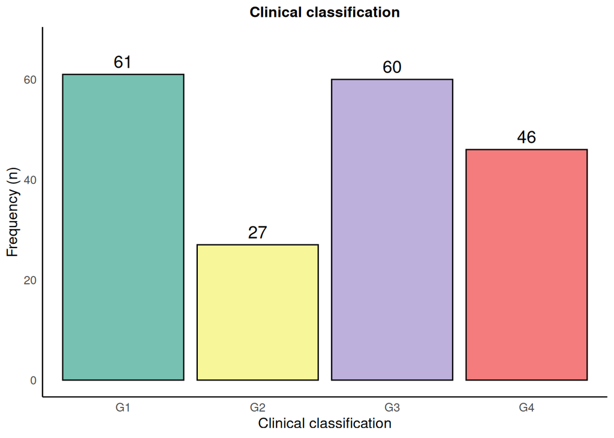

```r
# Filter data based on classification criteria
data <- data %>%
  filter(
    (`ARDS Diagnosis` == "No" & `Use of NIV` == "No" & `Use of AMV` == "No") |  # G1
    (`ARDS Diagnosis` == "No") |  # G2 allows any NIV and AMV when ARDS = No
    (`ARDS Diagnosis` == "Yes" & `Use of NIV` == "Yes" & `Use of AMV` == "No") |  # G3
    (`ARDS Diagnosis` == "Yes" & `Use of AMV` == "Yes")  # G4 allows any NIV
  )
#Introducing the classifications G1-4 to the data table
data <- data %>%
  mutate(
    Clinical_Classification = case_when(
      `ARDS Diagnosis` == "No" & `Use of NIV` == "No" & `Use of AMV` == "No" ~ "G1",
      `ARDS Diagnosis` == "No" ~ "G2",  # G2 allows any NIV and AMV when ARDS = No
      `ARDS Diagnosis` == "Yes" & `Use of NIV` == "Yes" & `Use of AMV` == "No" ~ "G3",
      `ARDS Diagnosis` == "Yes" & `Use of AMV` == "Yes" ~ "G4"  # G4 allows any NIV
    )
  )


# Count the number of observations per Clinical Classification group
classification_counts <- data %>%
  count(Clinical_Classification)

# Define custom colors (similar to your image)
custom_colors <- c("G1" = "#76C1B2", "G2" = "#F7F79A", "G3" = "#BDB0DD", "G4" = "#F47C7C")

# Create the bar plot
Plot1C <- ggplot(classification_counts, aes(x = Clinical_Classification, y = n, fill = Clinical_Classification)) +
  geom_bar(stat = "identity", color = "black") +
  geom_text(aes(label = n), vjust = -0.5, size = 5) +
  scale_fill_manual(values = custom_colors) +
  labs(
    title = "Clinical classification",
    x = "Clinical classification",
    y = "Frequency (n)"
  ) +
  ylim(0, max(classification_counts$n) * 1.1) +  # Extend y-axis
  theme_minimal() +
  theme(
    text = element_text(size = 12),
    plot.title = element_text(hjust = 0.5, size = 12, face = "bold"),
    legend.position = "none",
    panel.grid = element_blank(),  # Remove grid
    axis.line = element_line(color = "black")  # Add axis lines for clarity
  )
Plot1C
```

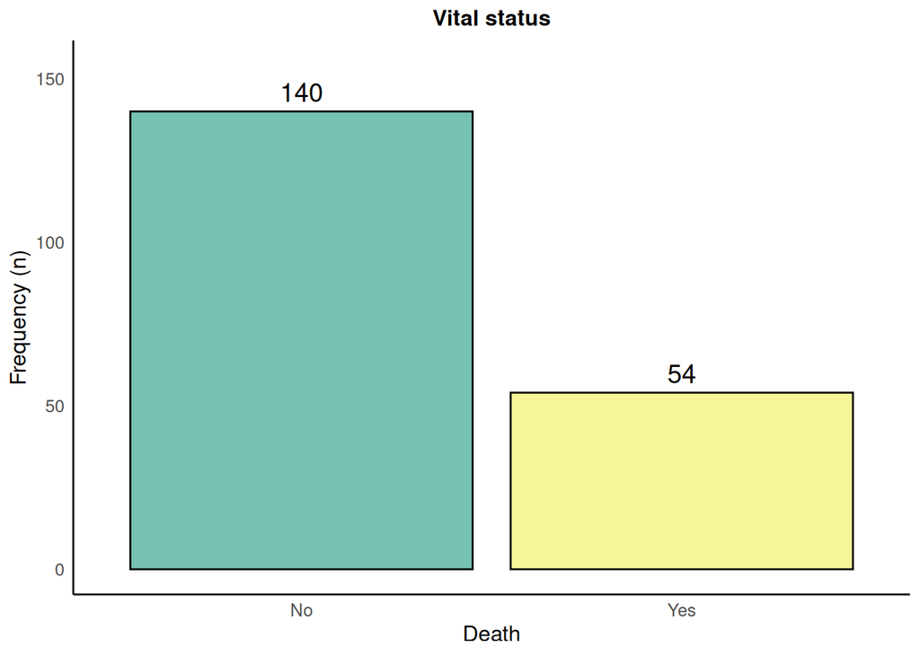

```r
# Count the number of occurrences of each category in the Death column
death_counts <- data %>%
  count(Death)

# Define custom colors
custom_colors2 <- c("No" = "#76C1B2", "Yes" = "#F7F79A")

# Create the bar plot
Plot1D <- ggplot(death_counts, aes(x = Death, y = n, fill = Death)) +
  geom_bar(stat = "identity", color = "black") +
  geom_text(aes(label = n), vjust = -0.5, size = 5) +
  scale_fill_manual(values = custom_colors2) +
  labs(
    title = "Vital status",
    x = "Death",
    y = "Frequency (n)"
  ) +
  ylim(0, max(death_counts$n) * 1.1) +  # Extend y-axis
  theme_minimal() +
  theme(
    text = element_text(size = 12),
    plot.title = element_text(hjust = 0.5, size = 12, face = "bold"),
    legend.position = "none",
    panel.grid = element_blank(),  # Remove grid
    axis.line = element_line(color = "black")  # Add axis lines
  )
Plot1D
```

Combining the plots Plot1A, Table_plot1B, Plot1C, Plot1D

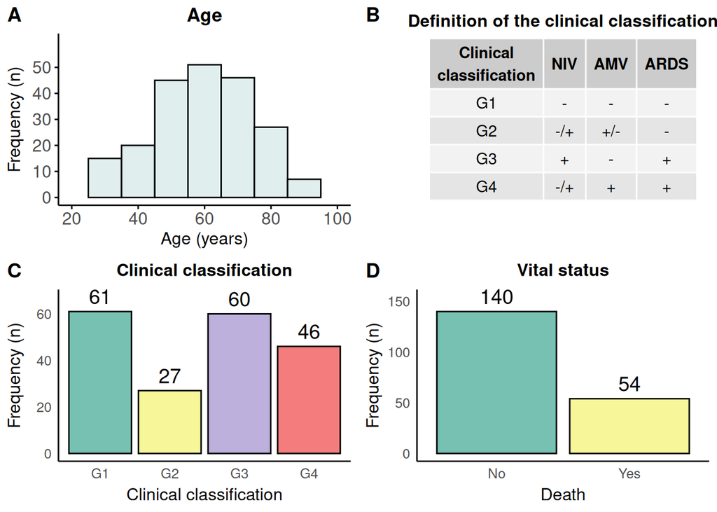

```r
final_plot <- ggarrange(
  Plot1A, table_plot1B, Plot1C, Plot1D,
  ncol = 2, nrow = 2,
  labels = c("A", "B", "C", "D"),  # Adds A, B, C, D labels
  font.label = list(size = 14, face = "bold"),
  widths = c(1, 1),
  heights = c(1, 1),
  align = "hv"
)
final_plot
```

```r
#ggsave("final_plot1.png", plot = final_plot, width = 8, height = 6, dpi = 300, bg = "white")
```

## Reproduce Figure 2 from the publication

but instead of representing the clusters in the annotation, represent the groups (G1 to G4)

```r
library(tidyverse)
library(readxl)
library(pheatmap)
library(RColorBrewer)
library(cluster)
library(grid)
library(ComplexHeatmap)
```

[output not shown]

```r
library(circlize)
```

```r
library(ggplot2)
#Loading the data and doing the necessary adjustments so that the excel file is  read correctly as a dataframe
data2 <-read_excel(here("data", "Table 2.XLSX"), skip = 1)
names(data2)[1] <- "ID"
data2 <- data2 %>%
  fill(ID, .direction = "down")
#Joining Clinical_Classification, Age, and Death from 'data' to 'data2' in one step and filling down duplicated values
data2 <- data2 %>%
  left_join(data %>% select(ID, Clinical_Classification, Gender, Death), by = "ID") %>%
  fill(Clinical_Classification, Gender, Death, .direction = "down")
#Making a dataset that contains the necessary data for clustering
data2_clustering <- data2 %>%
  select(1, 3:14, 28:30)
#Deleting rows with NI values
data2_clustering <- data2_clustering %>%
  filter(if_all(everything(), ~ . != "NI"))
#Checking the type of data
str(data2_clustering)
```

```
## tibble [327 × 16] (S3: tbl_df/tbl/data.frame)
##  $ ID                     : chr [1:327] "COAG-HSJD-001" "COAG-HSJD-002" "COAG-HSJD-003" "COAG-HSJD-003" ...
##  $ IL-1β                  : chr [1:327] "0" "0" "0" "0" ...
##  $ IL-6                   : chr [1:327] "4.5999999999999996" "0.5" "147.69999999999999" "169.5" ...
##  $ IL-10                  : chr [1:327] "4.0599999999999996" "9.16" "4.7" "0" ...
##  $ IFN-ɑ                  : chr [1:327] "2.69" "2.52" "0.4" "2.2815259999999999" ...
##  $ TNF-ɑ                  : chr [1:327] "0.72" "1.4" "0" "1.4033" ...
##  $ IL-8                   : chr [1:327] "37.619999999999997" "8.66" "133.52510000000001" "96.705349999999996" ...
##  $ G-CSF                  : chr [1:327] "3.7" "2.52" "10.344060000000001" "13.041069999999999" ...
##  $ IFN-γ                  : chr [1:327] "4.68" "3.72" "3.6417510000000002" "4.0869479999999996" ...
##  $ CCL3                   : chr [1:327] "4.07" "5.07" "20.068390000000001" "5.975409" ...
##  $ CXCL10                 : chr [1:327] "2387.96" "1490.02" "2135.7710000000002" "1025.501" ...
##  $ CCL2                   : chr [1:327] "58.88" "13.74" "901.47990000000004" "263.40839999999997" ...
##  $ IL-38                  : chr [1:327] "566.79" "655.42" "888.09339999999997" "951.71619999999996" ...
##  $ Clinical_Classification: chr [1:327] "G1" "G3" "G3" "G3" ...
##  $ Gender                 : chr [1:327] "F" "M" "M" "M" ...
##  $ Death                  : chr [1:327] "No" "No" "No" "No" ...
```

```r
#Because the data for the cytokines is not numeric we have to convert it to numeric.
data2_clustering <- data2_clustering %>%
  mutate(across(!c(ID, Clinical_Classification, Death, Gender), as.numeric))
#Getting error that NAs were introduced. This means that non-numeric data was present in the columns.
data2_clustering %>% summarise(across(everything(), ~ sum(is.na(.)), .names = "NA_count_{.col}"))
```

```
## # A tibble: 1 × 16
##   NA_count_ID `NA_count_IL-1β` `NA_count_IL-6` `NA_count_IL-10` `NA_count_IFN-ɑ`
##         <int>            <int>           <int>            <int>            <int>
## 1           0                0              27                0                0
## # ℹ 11 more variables: `NA_count_TNF-ɑ` <int>, `NA_count_IL-8` <int>,
## #   `NA_count_G-CSF` <int>, `NA_count_IFN-γ` <int>, NA_count_CCL3 <int>,
## #   NA_count_CXCL10 <int>, NA_count_CCL2 <int>, `NA_count_IL-38` <int>,
## #   NA_count_Clinical_Classification <int>, NA_count_Gender <int>,
## #   NA_count_Death <int>
```

```r
#27 NA were detected in IL-6 column. After checking at the original dataset, these data are ND values which means they were not detected.
#Since in the study they used all patients for the clustering, we impute these NAs with 0, since it was used for other patients.
data2_clustering <- data2_clustering %>%
  mutate(`IL-6` = ifelse(is.na(`IL-6`), 0, `IL-6`))
#Checking if the NAs were removed
data2_clustering %>% summarise(across(everything(), ~ sum(is.na(.)), .names = "NA_count_{.col}")) #They were removed
```

```
## # A tibble: 1 × 16
##   NA_count_ID `NA_count_IL-1β` `NA_count_IL-6` `NA_count_IL-10` `NA_count_IFN-ɑ`
##         <int>            <int>           <int>            <int>            <int>
## 1           0                0               0                0                0
## # ℹ 11 more variables: `NA_count_TNF-ɑ` <int>, `NA_count_IL-8` <int>,
## #   `NA_count_G-CSF` <int>, `NA_count_IFN-γ` <int>, NA_count_CCL3 <int>,
## #   NA_count_CXCL10 <int>, NA_count_CCL2 <int>, `NA_count_IL-38` <int>,
## #   NA_count_Clinical_Classification <int>, NA_count_Gender <int>,
## #   NA_count_Death <int>
```

```r
#Checking how many unique ID we have
data2_clustering %>% summarise(n_distinct(ID))
```

```
## # A tibble: 1 × 1
##   `n_distinct(ID)`
##              <int>
## 1              194
```

```r
#We have 194 unique IDs, which is the same number as in the article
#Calculating the mean for each cytokine for every patients accross days of sampling
data2_clustering <- data2_clustering %>%
  group_by(ID) %>%
  summarise(
    across(where(is.numeric), mean, na.rm = TRUE),  # Calculate the mean of numeric columns
    Clinical_Classification = first(Clinical_Classification),# Keep the first value of Clinical_Classification
    Death = first(Death),# Keep the first value of Death
    Gender = first(Gender) #Keep the first value of Gender
  )
data2_clustering %>% summarise(n_distinct(ID)) # We still have 194 IDs
```

```
## # A tibble: 1 × 1
##   `n_distinct(ID)`
##              <int>
## 1              194
```

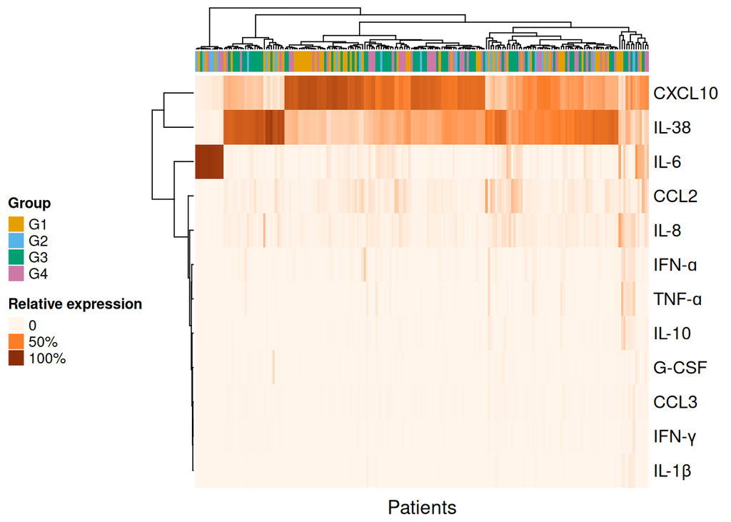

```r
# Begin the clustering
# Converting tibble to data frame
clustering_data <- as.data.frame(data2_clustering)
rownames(clustering_data) <- clustering_data$ID
clustering_data$ID <- NULL
# Ensure Clinical_Classification is a factor to maintain ordering
data2_clustering$Clinical_Classification <- factor(data2_clustering$Clinical_Classification,
                                                   levels = c("G1", "G2", "G3", "G4"))
# Sex and Death bring problems to the later analysis so we store them in a different data frame
Sex_Death <- clustering_data[,c(14,15)]
clustering_data <- clustering_data[,1:13]
# Create the heatmap data matrix (transposed)
heatmap_data <- t(clustering_data[, -ncol(clustering_data)])
# Calculating relative expression in percentage
relative_expression <- apply(heatmap_data, 2, function(x) (x / sum(x)) * 100)

# Preparing the annotations for the heatmap using colorblind friendly colors for G1-G4
annotation_data <- data.frame(Group = data2_clustering$Clinical_Classification)
group_annotation <- HeatmapAnnotation(df = annotation_data,
                                      show_annotation_name = FALSE,
                                      col = list(Group = c("G1" = "#E69F00", "G2" = "#56B4E9",
                                                           "G3" = "#009E73", "G4" = "#CC79A7")))

# Setting color scale for heatmap
heatmap_colors <- c("#FFF5EB", "#FB7D28", "#8C2D09")

# Creating the heatmap
heatmap_object <- Heatmap(relative_expression,
                          top_annotation = group_annotation,
                          col = colorRamp2(c(0, 50, 100), heatmap_colors),
                          column_title = "Patients",
                          column_title_side = "bottom",
                          show_column_names = FALSE,
                          show_heatmap_legend = FALSE)

# Adding a legend for relative expression values
color_legend <- Legend(
  title = "Relative expression",
  at = c(0, 50, 100),
  labels = c("0", "50%", "100%"),
  legend_gp = gpar(fill = heatmap_colors)
)

legend_pack <- packLegend(color_legend, direction = "vertical")

# Drawing the final heatmap with legend
final_heatmap_plot <- draw(heatmap_object, annotation_legend_list = legend_pack, annotation_legend_side = "left")
```

```r
#ggsave("final_heatmap.png", plot = grid.grabExpr(draw(heatmap_object,
    #annotation_legend_list = legend_pack, annotation_legend_side = "left")),
    #width = 10, height = 8, dpi = 150)
```

## Improve figure 2 of the publication

Add a second annotation with information of death and a third one with information of gender

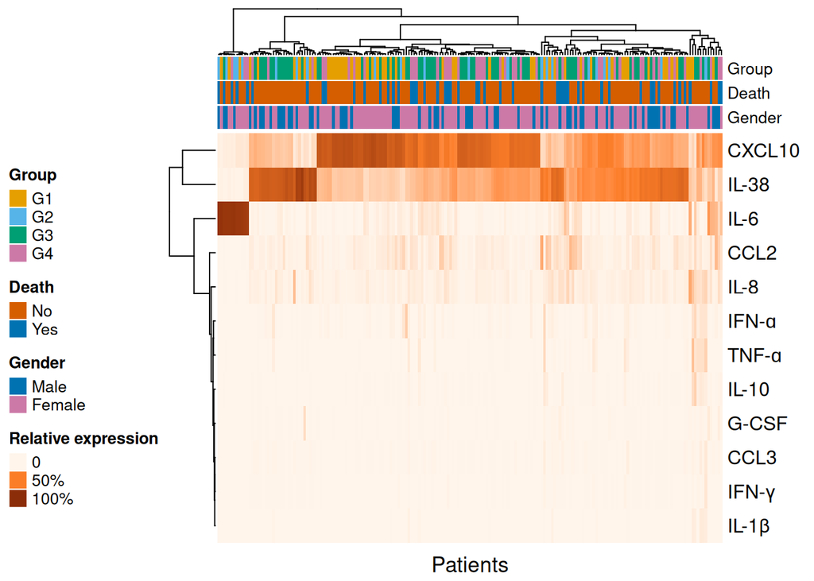

```r
annotation_data_final <- data.frame(
  Group = data2_clustering$Clinical_Classification,
  Death = factor(Sex_Death$Death),
  Gender = factor(Sex_Death$Gender)
)

# Check and set factor levels if necessary
levels(annotation_data_final$Death) <- c("No", "Yes")
levels(annotation_data_final$Gender) <- c("Male", "Female")

group_annotation <- HeatmapAnnotation(
  df = annotation_data_final,
  show_annotation_name = TRUE,
  col = list(
    Group = c("G1" = "#E69F00", "G2" = "#56B4E9", "G3" = "#009E73", "G4" = "#CC79A7"),
    Death = c("Yes" = "#0072B2", "No" = "#D55E00"),
    Gender = c("Male" = "#0072B2", "Female" = "#CC79A7")
  ),
  annotation_name_gp = gpar(fontsize = 10),
  annotation_height = unit(c(0.8, 0.4, 0.4), "cm")
)

heatmap_object_final <- Heatmap(
  relative_expression,
  top_annotation = group_annotation,
  col = colorRamp2(c(0, 50, 100), heatmap_colors),
  column_title = "Patients",
  column_title_side = "bottom",
  show_column_names = FALSE,
  show_heatmap_legend = FALSE
)

final_heatmap_plot <- draw(
  heatmap_object_final,  # Changed from heatmap_object to heatmap_object_final
  annotation_legend_list = legend_pack,
  annotation_legend_side = "left"
)
```

# session info

R version 4.4.1 (2024-06-14) Platform: x86_64-pc-linux-gnu Running under: Ubuntu 24.04.1 LTS

Matrix products: default BLAS: /usr/lib/x86_64-linux-gnu/openblas-pthread/libblas.so.3 LAPACK: /usr/lib/x86_64-linux-gnu/openblas-pthread/libopenblasp-r0.3.26.so; LAPACK version 3.12.0

locale: [1] LC_CTYPE=en_US.UTF-8 LC_NUMERIC=C  
[3] LC_TIME=en_US.UTF-8 LC_COLLATE=en_US.UTF-8  
[5] LC_MONETARY=en_US.UTF-8 LC_MESSAGES=en_US.UTF-8  
[7] LC_PAPER=en_US.UTF-8 LC_NAME=C  
[9] LC_ADDRESS=C LC_TELEPHONE=C  
[11] LC_MEASUREMENT=en_US.UTF-8 LC_IDENTIFICATION=C

time zone: Europe/Madrid tzcode source: system (glibc)

attached base packages: [1] grid stats graphics grDevices utils datasets methods  
[8] base

other attached packages: [1] circlize_0.4.16 ComplexHeatmap_2.20.0 cluster_2.1.6  
[4] pheatmap_1.0.12 RColorBrewer_1.1-3 ggpubr_0.6.0  
[7] readxl_1.4.5 patchwork_1.3.0 gridExtra_2.3  
[10] summarytools_1.1.2 corrplot_0.95 rcompanion_2.5.0  
[13] mice_3.17.0 GGally_2.2.1 lubridate_1.9.4  
[16] forcats_1.0.0 stringr_1.5.1 dplyr_1.1.4  
[19] purrr_1.0.4 readr_2.1.5 tidyr_1.3.1  
[22] tibble_3.2.1 ggplot2_3.5.1 tidyverse_2.0.0  
[25] magrittr_2.0.3 here_1.0.1 zCompositions_1.5.0-4 [28] truncnorm_1.0-9 NADA_1.6-1.1 survival_3.7-0  
[31] MASS_7.3-61 pacman_0.5.1

loaded via a namespace (and not attached): [1] libcoin_1.0-10 rstudioapi_0.17.1 jsonlite_1.9.1  
[4] shape_1.4.6.1 TH.data_1.1-3 jomo_2.7-6  
[7] modeltools_0.2-23 magick_2.8.5 farver_2.1.2  
[10] nloptr_2.1.1 rmarkdown_2.29 GlobalOptions_0.1.2 [13] vctrs_0.6.5 minqa_1.2.8 base64enc_0.1-3  
[16] rstatix_0.7.2 htmltools_0.5.8.1 haven_2.5.4  
[19] broom_1.0.7 cellranger_1.1.0 Formula_1.2-5  
[22] mitml_0.4-5 sass_0.4.9 bslib_0.9.0  
[25] plyr_1.8.9 sandwich_3.1-1 rootSolve_1.8.2.4  
[28] zoo_1.8-13 cachem_1.1.0 lifecycle_1.0.4  
[31] iterators_1.0.14 pkgconfig_2.0.3 Matrix_1.7-1  
[34] R6_2.6.1 fastmap_1.2.0 clue_0.3-66  
[37] rbibutils_2.3 digest_0.6.37 Exact_3.3  
[40] colorspace_2.1-1 S4Vectors_0.42.1 rprojroot_2.0.4  
[43] labeling_0.4.3 timechange_0.3.0 abind_1.4-8  
[46] httr_1.4.7 compiler_4.4.1 proxy_0.4-27  
[49] doParallel_1.0.17 bit64_4.6.0-1 withr_3.0.2  
[52] pander_0.6.6 backports_1.5.0 carData_3.0-5  
[55] ggstats_0.8.0 ggsignif_0.6.4 pan_1.9  
[58] rjson_0.2.23 gld_2.6.7 tools_4.4.1  
[61] lmtest_0.9-40 nnet_7.3-19 glue_1.8.0  
[64] nlme_3.1-165 checkmate_2.3.2 reshape2_1.4.4  
[67] generics_0.1.3 gtable_0.3.6 nortest_1.0-4  
[70] tzdb_0.4.0 class_7.3-22 data.table_1.17.0  
[73] lmom_3.2 hms_1.1.3 car_3.1-3  
[76] coin_1.4-3 utf8_1.2.4 BiocGenerics_0.50.0 [79] foreach_1.5.2 pillar_1.10.1 vroom_1.6.5  
[82] splines_4.4.1 pryr_0.1.6 lattice_0.22-5  
[85] bit_4.6.0 tidyselect_1.2.1 knitr_1.49  
[88] reformulas_0.4.0 IRanges_2.38.1 stats4_4.4.1  
[91] xfun_0.51 expm_1.0-0 rapportools_1.2  
[94] matrixStats_1.5.0 stringi_1.8.4 yaml_2.3.10  
[97] boot_1.3-30 evaluate_1.0.3 codetools_0.2-20  
[100] tcltk_4.4.1 multcompView_0.1-10 cli_3.6.4  
[103] rpart_4.1.23 DescTools_0.99.59 Rdpack_2.6.2  
[106] munsell_0.5.1 jquerylib_0.1.4 Rcpp_1.0.14  
[109] png_0.1-8 parallel_4.4.1 lme4_1.1-36  
[112] glmnet_4.1-8 mvtnorm_1.3-3 scales_1.3.0  
[115] e1071_1.7-16 crayon_1.5.3 GetoptLong_1.0.5  
[118] rlang_1.1.5 cowplot_1.1.3 multcomp_1.4-28